# Determinants of Household Size: A Socioeconomic Analysis Using Poisson Regression

# 1 Introduction

## 1.1 Background

Household structure is a fundamental indicator of socioeconomic development. Family size is influenced by income, housing conditions, demographic characteristics, and access to infrastructure. Understanding these relationships helps explain inequality patterns and living conditions within the region.

In particular, economic theory such as Engel’s Law suggests that lower-income households spend a larger proportion of income on food, which may also correlate with household size. Additionally, housing space constraints may limit family expansion.

## 1.2 Research Questions

The primary research question is:

What socioeconomic and demographic factors are associated with household size?

Sub-questions：

Is household size associated with household income and food expenditure?

Do demographic characteristics of the household head (age and sex) affect family size?

How do housing characteristics (floor area, number of bedrooms, house age) relate to household size?

## 1.3 Dataset Overview

The dataset contains 11 original variables:

| Variable | Description |
| --- | --- |
| Total.Household.Income | Annual household income (in Philippine Pesos) |
| Region | All households are from CAR region |
| Total.Food.Expenditure | Annual food expenditure (in Philippine Pesos) |
| Household.Head.Sex | Male/Female |
| Household.Head.Age | Age in years |
| Type.of.Household | Single Family / Extended Family / Non-related |
| Total.Number.of.Family.members | Household size |
| House.Floor.Area | Square meters |
| House.Age | Age of the house in years |
| Number.of.bedrooms | Count of bedrooms |
| Electricity | Whether household has electricity access (1=Yes, 0=No) |

# 2 Data

## 2.1 Data Structure

```
Dataset dimensions: 1725 rows, 18 columns
```

```
Variable types:
```

```
Rows: 1,725
Columns: 18
$ income         <int> 480332, 198235, 82785, 107589, 189322, 152883, 198621, …
$ region         <chr> "CAR", "CAR", "CAR", "CAR", "CAR", "CAR", "CAR", "CAR",…
$ food_exp       <int> 117848, 67766, 61609, 78189, 94625, 73326, 104644, 9564…
$ head_sex       <fct> Female, Male, Male, Male, Male, Male, Male, Male, Femal…
$ head_age       <int> 49, 40, 39, 52, 65, 46, 45, 33, 17, 53, 49, 35, 38, 53,…
$ hh_type        <fct> Extended Family, Single Family, Single Family, Single F…
$ family_size    <int> 4, 3, 6, 3, 4, 4, 5, 5, 2, 6, 4, 7, 7, 3, 2, 4, 5, 8, 4…
$ floor_area     <int> 80, 42, 35, 30, 54, 40, 35, 35, 35, 70, 40, 35, 35, 50,…
$ house_age      <int> 75, 15, 12, 15, 16, 7, 18, 48, 8, 12, 9, 17, 5, 43, 77,…
$ bedrooms       <int> 3, 2, 1, 1, 3, 2, 1, 2, 1, 3, 2, 3, 1, 3, 1, 1, 1, 1, 2…
$ electricity    <fct> 1, 1, 0, 1, 1, 1, 1, 1, 1, 1, 1, 1, 0, 1, 1, 1, 1, 1, 1…
$ income_log     <dbl> 13.08223, 12.19721, 11.32400, 11.58607, 12.15120, 11.93…
$ food_exp_log   <dbl> 11.67715, 11.12382, 11.02856, 11.26688, 11.45768, 11.20…
$ floor_area_log <dbl> 4.382027, 3.737670, 3.555348, 3.401197, 3.988984, 3.688…
$ food_ratio     <dbl> 24.53470, 34.18468, 74.42049, 72.67379, 49.98098, 47.96…
$ age_group      <fct> 40-49, 30-39, 30-39, 50-59, 60-69, 40-49, 40-49, 30-39,…
$ income_group   <fct> High, Upper-Middle, Low, Low, Upper-Middle, Lower-Middl…
$ bedrooms_group <fct> 3, 2, 1, 1, 3, 2, 1, 2, 1, 3, 2, 3, 1, 3, 1, 1, 1, 1, 2…
```

```
Missing values:
```

```
        income         region       food_exp       head_sex       head_age
             0              0              0              0              0
       hh_type    family_size     floor_area      house_age       bedrooms
             0              0              0              0              0
   electricity     income_log   food_exp_log floor_area_log     food_ratio
             0              0              0              0              0
     age_group   income_group bedrooms_group
             0              1              0
```

## 2.2 Summary Statistics

Summary Statistics of Numerical Variables

|  | income | food_exp | head_age | family_size | floor_area | house_age | bedrooms |
| --- | --- | --- | --- | --- | --- | --- | --- |
|  | Min. : 11988 | Min. : 6781 | Min. :17.00 | Min. : 1.000 | Min. : 5.00 | Min. : 0.00 | Min. :0.000 |
|  | 1st Qu.: 118565 | 1st Qu.: 51922 | 1st Qu.:41.00 | 1st Qu.: 3.000 | 1st Qu.: 32.00 | 1st Qu.: 12.00 | 1st Qu.:1.000 |
|  | Median : 188580 | Median : 73578 | Median :52.00 | Median : 4.000 | Median : 54.00 | Median : 20.00 | Median :2.000 |
|  | Mean : 269540 | Mean : 80353 | Mean :52.23 | Mean : 4.669 | Mean : 90.92 | Mean : 22.98 | Mean :2.259 |
|  | 3rd Qu.: 328335 | 3rd Qu.: 98493 | 3rd Qu.:63.00 | 3rd Qu.: 6.000 | 3rd Qu.:102.00 | 3rd Qu.: 31.00 | 3rd Qu.:3.000 |
|  | Max. :6042860 | Max. :327724 | Max. :99.00 | Max. :15.000 | Max. :900.00 | Max. :100.00 | Max. :9.000 |

The summary statistics reveal substantial heterogeneity across households. In particular, household income, food expenditure, and floor area exhibit clear right-skewness. For these variables, the mean values are considerably larger than their corresponding medians, and the maximum values are far above the upper quartiles. This indicates the presence of a small number of households with exceptionally high income, expenditure, or housing size, which generate long right tails in the distributions.

In contrast, household head age appears approximately symmetric, as the mean and median are nearly identical. The response variable, household size, shows mild right-skewness, with a mean (4.67) slightly exceeding the median (4), and a maximum value of 15 suggesting the presence of larger households.

Given the strong skewness observed in income-related and housing-size variables, logarithmic transformations are considered in subsequent modelling to reduce the influence of extreme values and improve the linearity assumption within the GLM framework.

# 3 Exploratory Data Analysis

## 3.1 Income and Expenditure Patterns

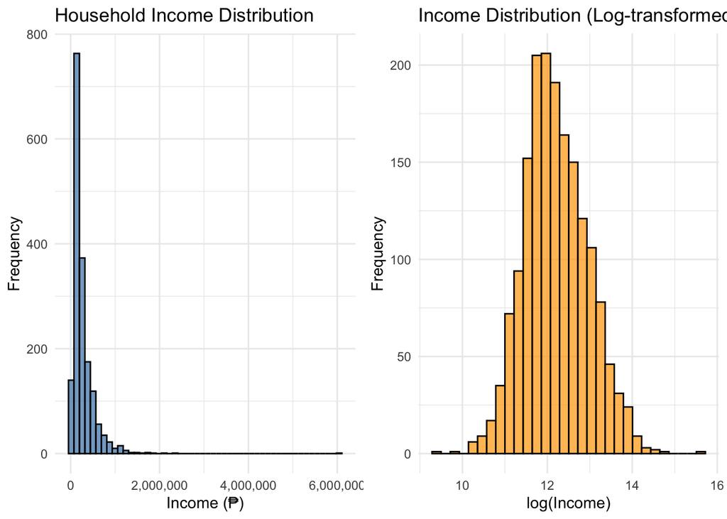

Income Statistics

| Statistic | Value |
| --- | --- |
| Minimum | 11988 |
| Q1 | 118565 |
| Median | 188580 |
| Mean | 269540 |
| Q3 | 328335 |
| Maximum | 6042860 |
| SD | 274564 |

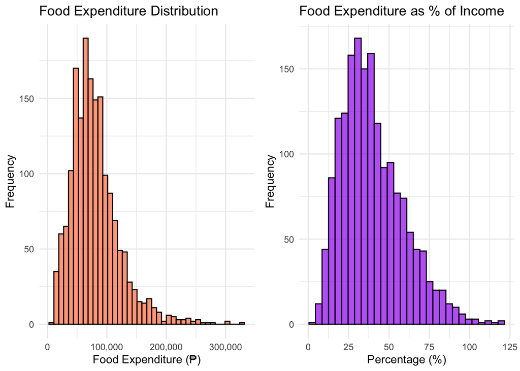

Food Expenditure Statistics

| Statistic | Food_Exp | Percent_of_Income |
| --- | --- | --- |
| Minimum | 6781 | 2.482202 |
| Q1 | 51922 | 25.656115 |
| Median | 73578 | 36.781821 |
| Mean | 80353 | 39.900000 |
| Q3 | 98493 | 51.517169 |
| Maximum | 327724 | 119.637272 |

Exploratory analysis shows that household income is highly right-skewed. The mean income exceeds the median, indicating income inequality within the sample. Log transformation reduces skewness and improves suitability for regression modelling.

Food expenditure is positively associated with income. However, the food-to-income ratio declines as income increases, consistent with Engel’s Law. Lower-income households allocate a greater share of income to food consumption, suggesting higher economic vulnerability.

## 3.2 Demographic and Housing Characteristics

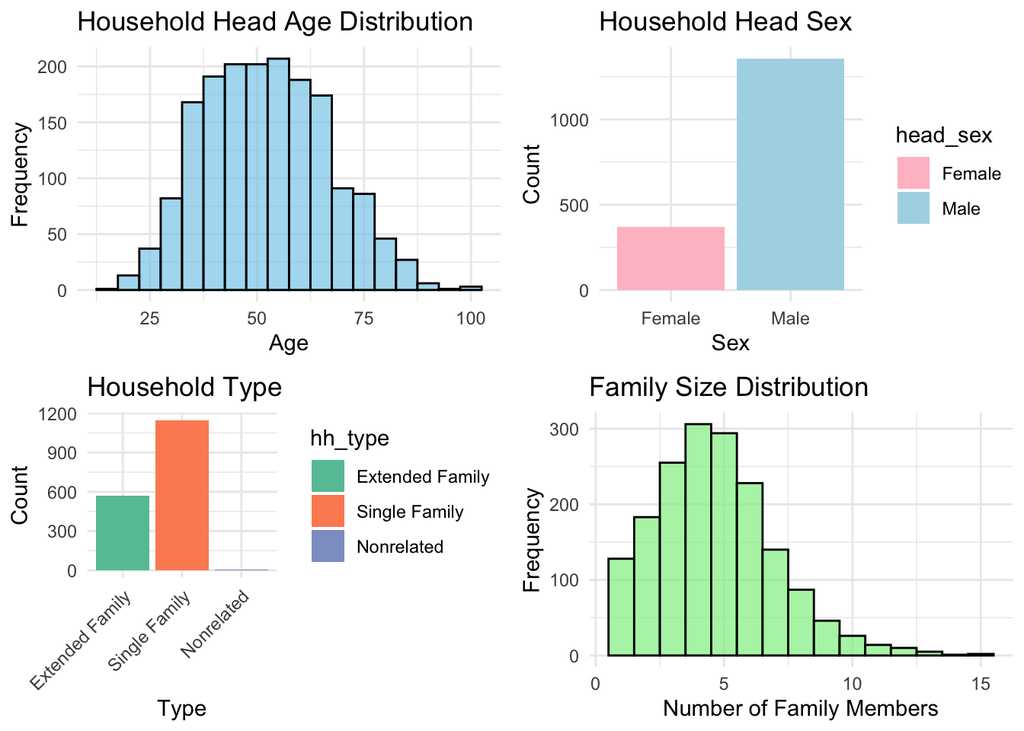

Age Group Distribution

| age_group | Count | Percentage |
| --- | --- | --- |
| <30 | 91 | 5.3 |
| 30-39 | 322 | 18.7 |
| 40-49 | 408 | 23.7 |
| 50-59 | 393 | 22.8 |
| 60-69 | 319 | 18.5 |
| 70+ | 192 | 11.1 |

Gender Distribution

| head_sex | Count | Percentage |
| --- | --- | --- |
| Female | 369 | 21.4 |
| Male | 1356 | 78.6 |

Household Type Distribution

| hh_type | Count | Percentage |
| --- | --- | --- |
| Extended Family | 569 | 33.0 |
| Single Family | 1148 | 66.6 |
| Two or More Nonrelated Persons/Members | 8 | 0.5 |

The age distribution of household heads is approximately bell-shaped, with most individuals concentrated between 40 and 60 years old. Gender distribution is imbalanced, with male-headed households accounting for 78.6% of the sample.

Household types are predominantly single-family units (66.6%), followed by extended families (33.0%), while non-related shared households are rare (0.5%). Family size shows mild right-skewness, with most households containing 3–6 members.

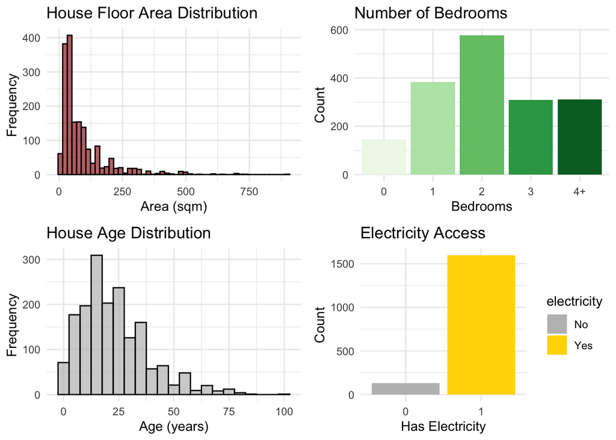

Bedroom Distribution

| bedrooms_group | Count | Percentage |
| --- | --- | --- |
| 0 | 145 | 8.4 |
| 1 | 383 | 22.2 |
| 2 | 577 | 33.4 |
| 3 | 309 | 17.9 |
| 4+ | 311 | 18.0 |

Electricity Access

| electricity | Count | Percentage |
| --- | --- | --- |
| 0 | 129 | 7.5 |
| 1 | 1596 | 92.5 |

Housing characteristics exhibit stronger skewness. Floor area distribution is heavily right-skewed, indicating the presence of a small number of very large properties. Similarly, house age shows moderate right-skewness. Electricity access is nearly universal (92.5%), suggesting limited variation in this variable.

These structural patterns suggest potential nonlinear effects and skewness in key housing variables, motivating transformation considerations in the modelling stage.

## 3.3 Correlation Structure

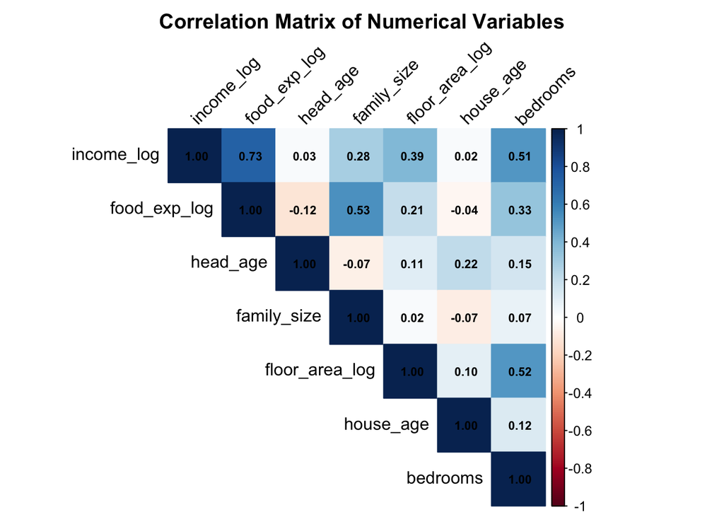

Overall, no extremely high correlations are observed, indicating that severe multicollinearity is unlikely. These patterns support the inclusion of income, expenditure, and housing variables in the formal modelling stage.

## 3.4 Key Findings from EDA

The exploratory analysis reveals substantial heterogeneity across both economic and housing characteristics. Income and food expenditure exhibit clear right-skewed distributions, with means substantially exceeding medians and extreme maximum values, indicating the presence of high-income households that drive the upper tail. A similar right-skewness is observed in floor area, where a small number of very large houses inflate the mean relative to the median. These patterns suggest that log-transformations may be appropriate for modelling continuous economic variables.

Demographic characteristics show a relatively balanced age distribution, with most household heads concentrated between 40 and 60 years old. The gender distribution is highly asymmetric, with male-headed households representing the majority of observations. Household structure is dominated by single-family households, while extended families account for approximately one-third of the sample, and nonrelated cohabitation is rare.

Family size is moderately right-skewed, with most households consisting of 3–6 members, but with a small number of larger households. Housing characteristics further indicate that most dwellings contain 1–3 bedrooms, and the vast majority of households have access to electricity, suggesting relatively high infrastructure coverage within the sampled population.

# 4 Function data analysis

## 4.1 Variable Selection

```
Model0: family_size ~ income+food_exp+head_sex+hh_type+floor_area+house_age+bedrooms+electricity
```

```
AIC:  7022.27
```

```
BIC:  7076.8
```

```
                                                    p-value
(Intercept)                                   2.475326e-101
income                                         5.207881e-04
food_exp                                       2.261168e-51
head_sexMale                                   1.268634e-15
hh_typeSingle Family                           2.795682e-43
hh_typeTwo or More Nonrelated Persons/Members  4.653603e-01
floor_area                                     9.861097e-02
house_age                                      4.122995e-04
bedrooms                                       4.297131e-02
electricity1                                   4.458529e-01
```

```
Model1: family_size ~ income+food_exp+head_sex+hh_type_binary+house_age+bedrooms
```

```
AIC:  7020.111
```

```
BIC:  7058.282
```

```
                                  p-value
(Intercept)                 2.816001e-182
income                       1.944734e-04
food_exp                     6.242706e-53
head_sexMale                 5.593335e-16
hh_type_binarySingle Family  2.715163e-43
house_age                    3.465800e-04
bedrooms                     1.269987e-02
```

```
Model2: family_size ~ income_log+food_exp_log+cate_variable+house_age+bedrooms
```

```
AIC:  6864.889
```

```
BIC:  6903.06
```

```
                                 p-value
(Intercept)                 3.201535e-37
income_log                  7.242597e-07
food_exp_log                3.065088e-71
head_sexMale                1.078425e-11
hh_type_binarySingle Family 6.112934e-34
house_age                   1.290496e-02
bedrooms                    1.203602e-02
```

Both AIC and BIC have decreased. The final model should be:

$$log(\mu_i) = \beta_0 + \beta_1\cdot log({Income}_i) + \beta_2\cdot log({FoodExpenditure}_i) + \beta_3\cdot \mathbb{I}_{HeadSex_i} \\
+ \beta_4\cdot \mathbb{I}_{HouseholdType_i} + \beta_5\cdot {HouseAge}_i + \beta_6\cdot {Bedrooms}$$
The results of the final model is shown as follows.

The Poisson model -- Incidence Rate Ratios with 95% CIs

| Term | IRR | SE | z | p | CI low | CI high |
| --- | --- | --- | --- | --- | --- | --- |
| (Intercept) | 0.024 | 0.292 | -12.748 | 0.000 | 0.014 | 0.043 |
| income_log | 0.885 | 0.025 | -4.955 | 0.000 | 0.844 | 0.929 |
| food_exp_log | 1.842 | 0.034 | 17.847 | 0.000 | 1.723 | 1.970 |
| head_sexMale | 1.222 | 0.029 | 6.796 | 0.000 | 1.153 | 1.295 |
| hh_type_binarySingle Family | 0.748 | 0.024 | -12.145 | 0.000 | 0.714 | 0.784 |
| house_age | 0.998 | 0.001 | -2.486 | 0.013 | 0.997 | 1.000 |
| bedrooms | 0.977 | 0.009 | -2.511 | 0.012 | 0.959 | 0.995 |

The Poisson regression results indicate that several socioeconomic and demographic factors are significantly associated with household size. Income has a negative effect (IRR = 0.885), suggesting that higher-income households tend to have smaller family sizes after controlling for other characteristics. In contrast, food expenditure shows a strong positive association (IRR = 1.842), likely reflecting its relationship with overall household scale. Male-headed households are associated with larger family sizes, while single-family households tend to be smaller compared to extended households. Although house age and number of bedrooms are statistically significant, their effects are relatively modest in magnitude. Overall, the model identifies meaningful structural and economic influences on household size.

## 4.2 Visualization for Relationship

To better understand how the variables influence the number of family members, plots of fitted value vs variables are shown as follows.

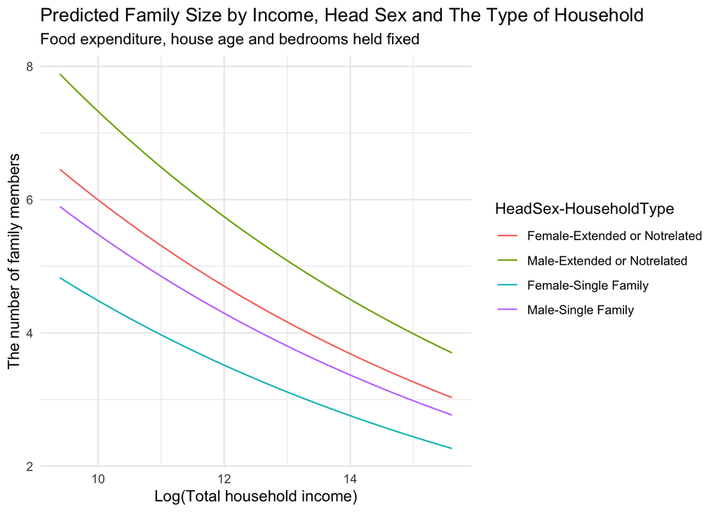

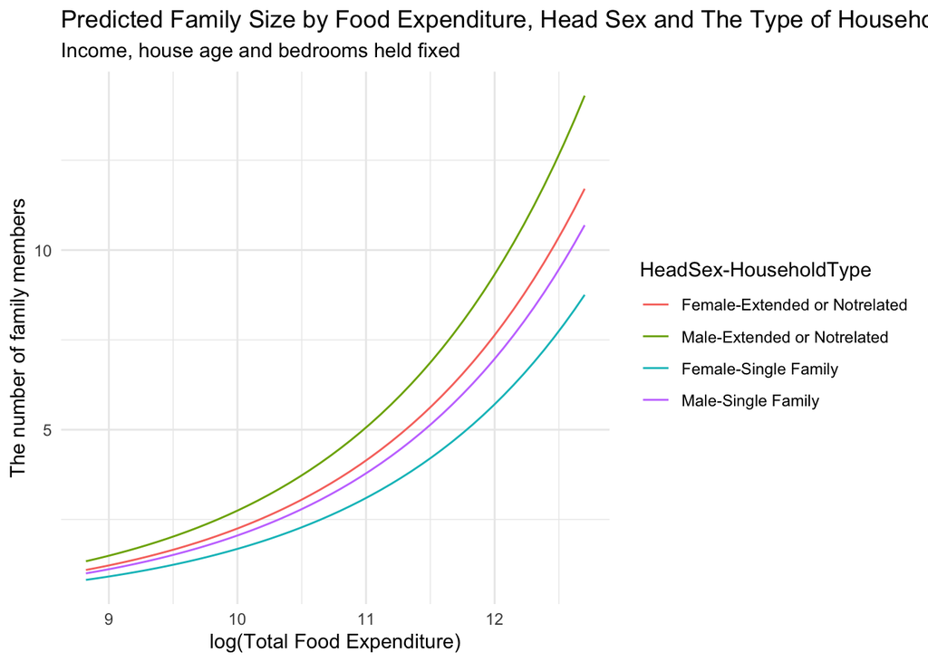

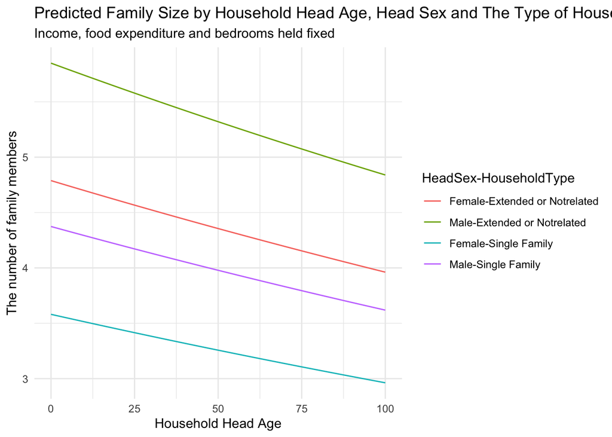

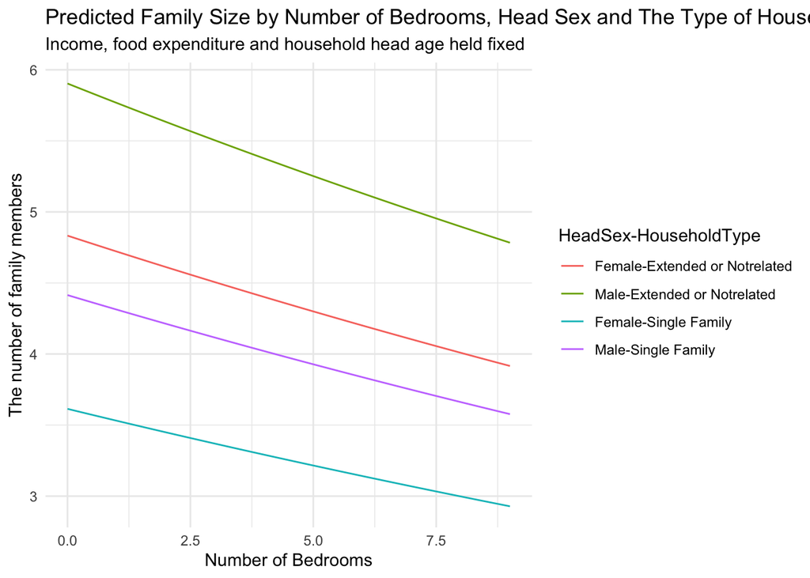

The predicted plots illustrate how household size varies with key socioeconomic variables under the Poisson model. Income appears negatively associated with family size, whereas food expenditure shows a positive relationship. Differences across household type and head sex persist even after controlling for other covariates, indicating structural demographic effects.

Although income exhibits a positive simple correlation with household size, the Poisson regression reveals a negative conditional effect after controlling for housing and expenditure variables. This suggests that higher-income households tend to have smaller family sizes once structural housing capacity is accounted for, consistent with demographic transition theory.

# 5 Assessing Model Fit

## 5.1 Deviance Analysis

The goodness of fit of a Poisson model can be measured by the null deviance and residual deviance. The model can be compared with the null model using a likelihood ratio test.

```
p-value of likelihood ratio test:  0
```

Hence the model is significantly better than the null model.

## 5.2 Observed vs Fitted Values under the Poisson Model

The plot of fitted value and true value can also be shown to see how well the model fit the data.

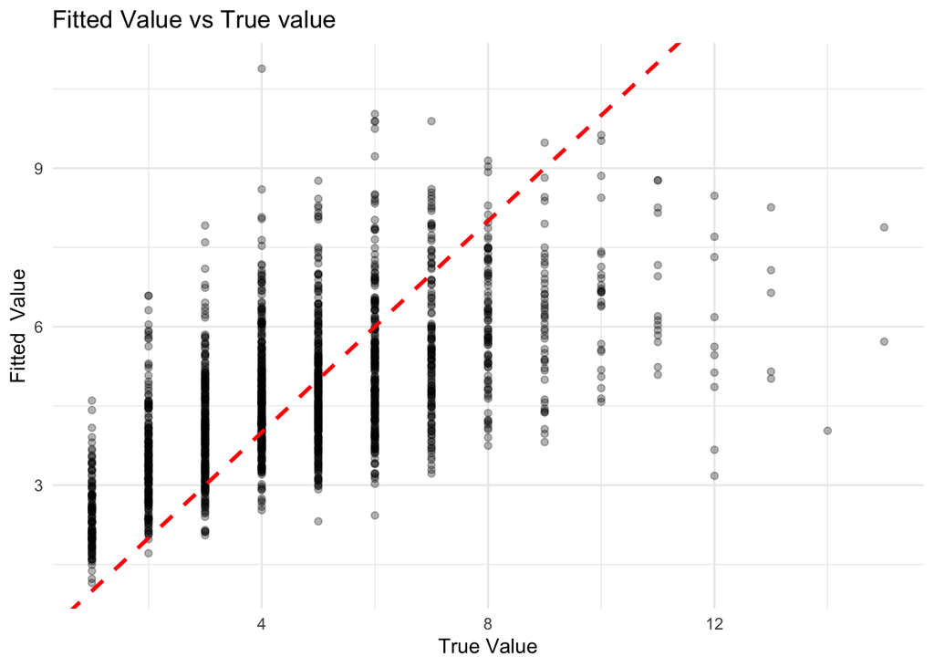

The scatter plot shows fitted versus observed household size, with the red dashed line representing perfect prediction. While the model captures the overall increasing pattern, substantial dispersion around the reference line suggests moderate prediction error, particularly for larger households.

## 5.3 Overdispersion

To see whether the Quasipoisson should be used to fitted the data, residual deviance and Pearson $\chi^2$ of the model can be printed.

```
Deviance-based dispersion: 0.692
```

```
Pearson-based dispersion: 0.717
```

The ratio of residual deviance to degrees of freedom is smaller than 1, so there is no evidence of severe overdispersion. Hence the Quasipoisson and he Negative Binomial is not necessary.

# 6 Conclusion

This study investigated the socioeconomic and housing characteristics of households using a combination of exploratory data analysis and regression modelling. The descriptive analysis highlighted substantial variation in income, food expenditure, and housing size, with clear evidence of right-skewed distributions in key economic variables. Demographic patterns revealed a predominance of middle-aged, male-headed, single-family households, alongside high levels of electricity access.

The modelling results suggest that household economic behaviour is influenced by both demographic and structural housing characteristics. However, the skewed nature of several continuous variables indicates that careful model specification and potential transformations are necessary to ensure valid inference.

Overall, the findings provide insight into the distributional structure of household socioeconomic conditions and demonstrate the importance of combining exploratory diagnostics with appropriate statistical modelling strategies. Future work could extend this analysis by incorporating interaction effects, non-linear specifications, or alternative model families to better capture heterogeneity across households.